# Springer Examples

Sarah Formentini

October 31, 2019

# Loading the data

See Pull Data.R for the code to create the `.Rdata` file.

```r
load("Data/GSE2034.Rdata")

Data <- data.frame(X,Y=Y,Censor=Censor)
```

# Study Introduction: GSE2034

[Link](https://www.ncbi.nlm.nih.gov/geo/query/acc.cgi?acc=gse2034)  
##Summary

> This series represents 180 lymph-node negative relapse free patients and 106 lymph-node negate patients that developed a distant metastasis.

Y. Wang, J. G. Klijn, Y. Zhang, A. M. Sieuwerts, M. P. Look, F. Yang,D. Talantov, M. Timmermans, M. E. Meijer-Van Gelder, J. Yu, T. Jatkoe,E. M. Berns, D. Atkins, J. A. Foekens: Gene-expression profiles to predictdistant metastasis of lymph-node-negative primary breast cancer, Lancet365, 671–679 (2005) doi:10.1016/S0140-6736(05)70933-8

## Initial Feature Screening: Marginal Screening and Gene Signature

Run univariate Cox proportional hazards to find the variables with the most significant marginal relationship to survival.

```r
weights <- numeric(dim(X)[2])
for(i in 1:dim(X)[2]){
  weights[i] <- summary(coxph(Surv(Y, Censor)~X[,i]))$coefficients[5]
}

topX <- colnames(X)[order(weights)[1:500]]
```

The Gene_signature.txt file contains a list of the 76 variables included in the gene signature from Wang et al.

```r
Gene_signature <- read.table("Data/Gene_signature.txt", header=TRUE, quote="\"", stringsAsFactors=FALSE)
```

Combined the maginal screening and signature variables and create a reduced X matrix and data.frame.

```r
combX <- unique(c(topX,Gene_signature$X))

Xr <- X[,colnames(X) %in% combX]

Data <- data.frame(Xr,ER=GSE2034_Clinical$`ER Status`,Y=Y,Censor=Censor)

Xr <- Data[,-c(554:555)]
```

## Data Exploration

Fit two initial survival functions based on ER status, which Wang et al. used to stratify their data.

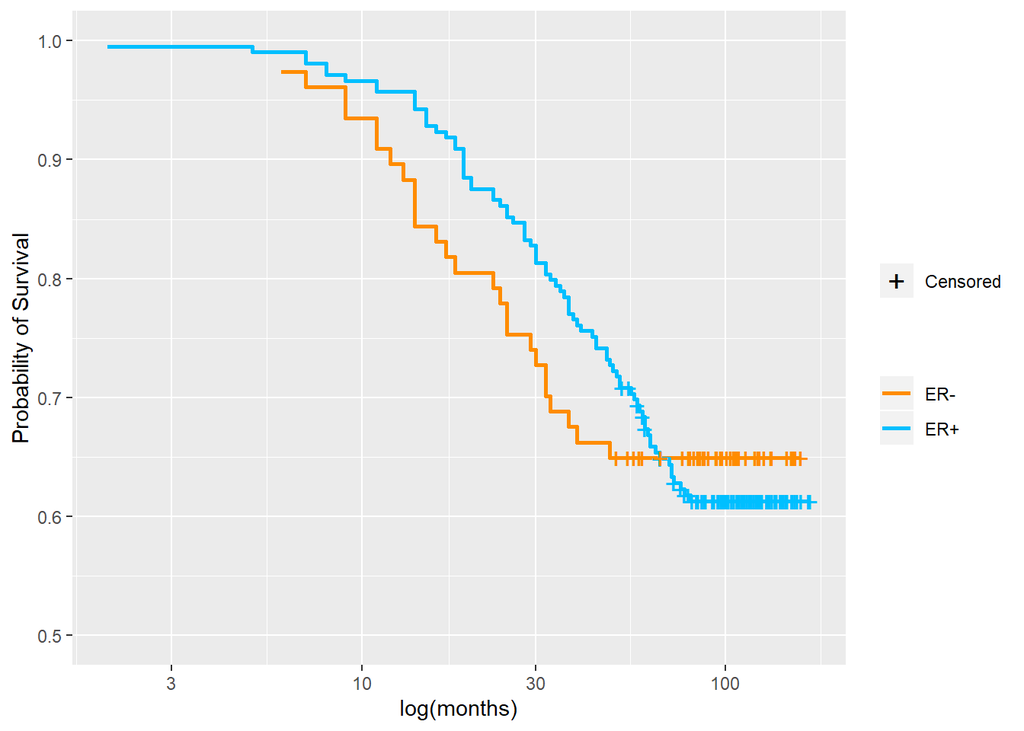

```r
ERp<-survfit(Surv(Y,Censor)~1,data=Data[GSE2034_Clinical$`ER Status`=="ER+",])
ERn<-survfit(Surv(Y,Censor)~1,data=Data[GSE2034_Clinical$`ER Status`=="ER-",])
plot_frame <- data.frame(Time=c(ERp$time,ERn$time),Survival=c(ERp$surv,ERn$surv),C=c(ifelse(ERp$n.censor>0,"Censored",NA),ifelse(ERn$n.censor>0,"Censored",NA)),ER=c(rep("ER+",length(ERp$time)),rep("ER-",length(ERn$time))))
ggplot(plot_frame,aes(x=Time,y=Survival))+geom_step(aes(x=Time,y=Survival,col=ER),size=1,show.legend = TRUE) + scale_shape_manual(na.translate=FALSE,values="+")+geom_point(aes(shape=C,col=ER),size=5,na.rm = TRUE,show.legend = TRUE, position = "jitter")+scale_color_manual(values=c("darkorange","deepskyblue"))+xlab("log(months)")+ylab("Probability of Survival")+ guides(col = guide_legend(title = "",, override.aes = list( shape='')), shape=guide_legend(title = "", override.aes = list(linetype = 0)))+ylim(0.5,1)+scale_x_log10()
```

```r
ggsave("Plots/Zhu_SurvAnalysis_MargbyER.png")
```

Number of failures and failure rate:

```r
sum(Censor)
```

```
## [1] 107
```

```r
sum(Censor)/length(Censor)
```

```
## [1] 0.3741259
```

## Model Fitting

Parameters tested for optimal model

```r
mtry_ops <- c(sqrt(dim(Xr)[2]+1),(dim(Xr)[2]+1)/3,dim(Xr)[2]+1)
ns_ops <- c(1,log(length(Y)),log(sum(Censor)))
param_tunings <- expand.grid(mtry=mtry_ops, ns=ns_ops, split.gen=c("best","random"))
```

Tuning the model by running through the possible parameters

```r
param_tunings$oob_err <- NA
for(i in 1:dim(param_tunings)[1]){
  set.seed(2+i)
  fit_ops <- RLT(Xr,Y,Censor, nmin = param_tunings$ns[i], mtry = param_tunings$mtry[i], nsplit = ifelse(param_tunings$split.gen[i]=="best",0,1), split.gen =param_tunings$split.gen[i], ntrees = 1000, importance = FALSE, replacement = TRUE, resample.prob = 1)
  param_tunings$oob_err[i]<-fit_ops$cindex
}
```

[output not shown]

```r
mtry_opt <- param_tunings$mtry[param_tunings$oob_err==min(param_tunings$oob_err)]
ns_opt <- param_tunings$ns[param_tunings$oob_err==min(param_tunings$oob_err)]
splitgen_opt <- param_tunings$split.gen[param_tunings$oob_err==min(param_tunings$oob_err)]
```

The optimal parameters

```r
param_tunings
```

```
##        mtry       ns split.gen   oob_err
## 1   23.5372 1.000000      best 0.2713659
## 2  184.6667 1.000000      best 0.2944081
## 3  554.0000 1.000000      best 0.2944894
## 4   23.5372 5.655992      best 0.2581582
## 5  184.6667 5.655992      best 0.2639899
## 6  554.0000 5.655992      best 0.2824603
## 7   23.5372 4.672829      best 0.2623847
## 8  184.6667 4.672829      best 0.2737839
## 9  554.0000 4.672829      best 0.2818710
## 10  23.5372 1.000000    random 0.2613281
## 11 184.6667 1.000000    random 0.2699842
## 12 554.0000 1.000000    random 0.2738448
## 13  23.5372 5.655992    random 0.2697810
## 14 184.6667 5.655992    random 0.2675052
## 15 554.0000 5.655992    random 0.2682367
## 16  23.5372 4.672829    random 0.2633600
## 17 184.6667 4.672829    random 0.2667940
## 18 554.0000 4.672829    random 0.2691307
```

```r
mtry_opt
```

```
## [1] 23.5372
```

```r
ns_opt
```

```
## [1] 5.655992
```

```r
splitgen_opt
```

```
## [1] best
## Levels: best random
```

```r
max(param_tunings$oob_err)/min(param_tunings$oob_err)
```

```
## [1] 1.140732
```

Fitting the optimal model

```r
fit_opt <- RLT(Xr,Y,Censor, nmin = ns_opt, mtry = mtry_opt, nsplit = ifelse(splitgen_opt=="best",0,1),
               split.gen =splitgen_opt, ntrees = 1000, importance = TRUE, replacement = TRUE, resample.prob=1)
```

```
##  run survival forest
##  --- survForestBuild
```

```r
pred_opt <- predict(fit_opt)
```

## Variable importance

Finding the top variable

```r
VI1 <- colnames(Xr)[fit_opt$VarImp==max(fit_opt$VarImp)][1]
VI1
```

```
## [1] "X217476_at"
```

Plotting the top 40 variable importance

```r
VI <- data.frame(id=c(1:(dim(Xr)[2])),variable=substring(colnames(Xr),2),vi=fit_opt$VarImp,signature=c(colnames(Xr))%in%paste0("X",Gene_signature$X))
VI <- VI[order(VI$vi),]
VI$ord <- c(1:(dim(Xr)[2]))
VI$variable <- factor(VI$variable, levels = VI$variable[order(VI$vi)])
head(VI)
```

```
##      id    variable           vi signature ord
## 83   83 202998_s_at -0.003959706     FALSE   1
## 474 474 219312_s_at -0.002588205     FALSE   2
## 39   39 201608_s_at -0.002386573     FALSE   3
## 465 465   218919_at -0.002054588     FALSE   4
## 433 433   218252_at -0.001983294     FALSE   5
## 478 478   219478_at -0.001935734     FALSE   6
```

```r
tail(VI)
```

```
##      id    variable          vi signature ord
## 85   85 203141_s_at 0.002864308     FALSE 548
## 357 357   215028_at 0.002910646     FALSE 549
## 256 256 210028_s_at 0.003052507      TRUE 550
## 123 123 204319_s_at 0.003072042     FALSE 551
## 273 273 211000_s_at 0.003298915     FALSE 552
## 413 413   217476_at 0.004167099     FALSE 553
```

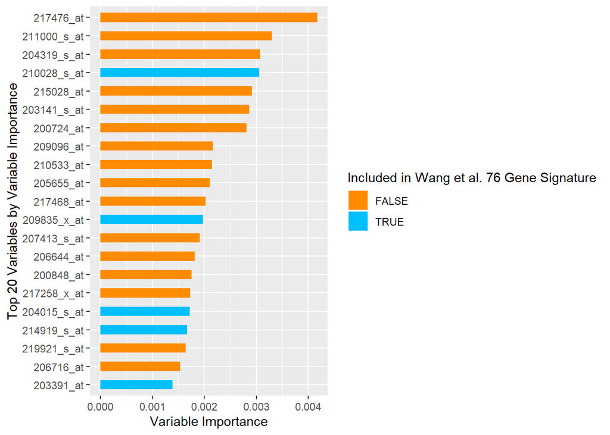

```r
ggplot(VI[(dim(VI)[1]-20):dim(VI)[1],],aes(x=variable,y=vi,fill=signature))+geom_col(width = 0.5,show.legend = TRUE)+scale_fill_manual(values=c("darkorange","deepskyblue"))+ylab("Variable Importance")+xlab("Top 20 Variables by Variable Importance")+coord_flip() + guides(fill = guide_legend(title = "Included in Wang et al. 76 Gene Signature"))
```

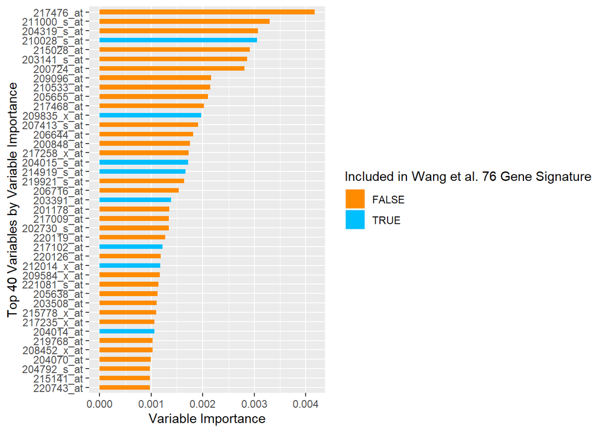

```r
ggsave("Plots/Zhu_SurvAnalysis_Top20VI.png")
ggplot(VI[(dim(VI)[1]-40):dim(VI)[1],],aes(x=variable,y=vi,fill=signature))+geom_col(width = 0.5,show.legend = TRUE)+scale_fill_manual(values=c("darkorange","deepskyblue"))+ylab("Variable Importance")+xlab("Top 40 Variables by Variable Importance")+coord_flip() + guides(fill = guide_legend(title = "Included in Wang et al. 76 Gene Signature"))
```

```r
ggsave("Plots/Zhu_SurvAnalysis_Top40VI.png")
```

## Plotting survival curves

Reshaping the survival curves so they can be more easily plotted

```r
surv_oob <- sapply(c(1:dim(fit_opt$OOBPrediction)[1]),function(i) exp(-cumsum(fit_opt$OOBPrediction[i,])))
surv <- data.frame(fit_opt$timepoints,surv_oob)
melted <- melt(surv,1)
truth <- data.frame(subj=paste0("X",c(1:dim(Xr)[1])),Y=Data[,"Y"],ER=Data[,553],MaxVar=Data[,VI1])
colnames(melted) <- c("Time", "Subject", "Probability")
melted <- merge(melted, truth, by.x="Subject", by.y="subj",all.x=TRUE)
```

Pulling the subjects within ER+ and ER- which have the highest and lowest values of the most important variable.

```r
ERnL<-which(Data[[VI1]]==min(Data[[VI1]][Data$ER=="ER-"&Censor==1]))[1]
ERpL<-which(Data[[VI1]]==min(Data[[VI1]][Data$ER=="ER+"&Censor==1]))[1]
ERnH<-which(Data[[VI1]]==max(Data[[VI1]][Data$ER=="ER-"&Censor==1]))[1]
ERpH<-which(Data[[VI1]]==max(Data[[VI1]][Data$ER=="ER+"&Censor==1]))[1]
c(ERnL,ERpL,ERnH,ERpH)
```

```
## [1]  66 130   5 270
```

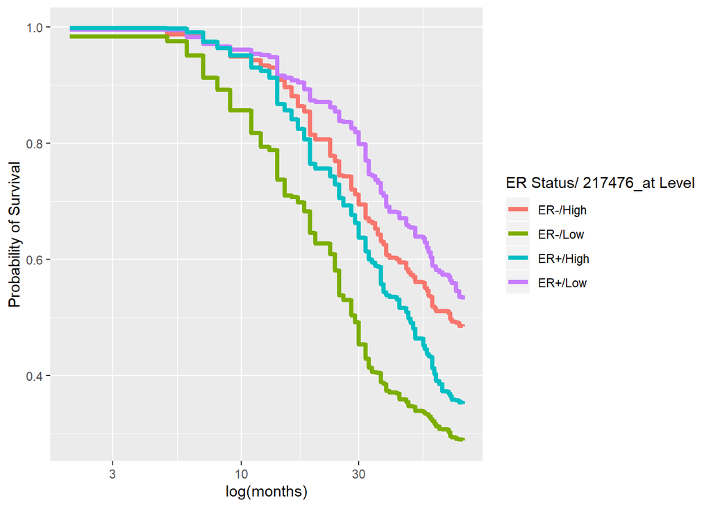

```r
Lev <- data.frame(Subject=paste0("X",c(ERnL,ERpL,ERnH,ERpH)), Level=c("ER-/Low","ER+/Low","ER-/High","ER+/High"))

melted2 <- melted[melted$Subject %in% paste0("X",c(ERnL,ERpL,ERnH,ERpH)),]
melted2$Level <- sapply(as.character(melted2$Subject),function(s) Lev$Level[Lev$Subject==s])

ggplot(melted2,aes(x=Time,y=Probability))+geom_step(aes(group=Subject,col=Level),show.legend = TRUE,size=1.5)+ylab("Probability of Survival")+xlab("log(months)")+scale_x_log10() + guides(col = guide_legend(title = paste0("ER Status/ ",substring(VI1,2) ," Level")))
```

```r
ggsave("Plots/Zhu_SurvAnalysis_TestPredsStrat.png")
```

## Error calculations

Brier Score and C-index functions

```r
Brier_Score <- function(surv, Censor, Ytest, tmpts){
  KM <- survfit(Surv(Ytest,!Censor)~1)#Estimation of Censoring Distribution
  BS <- numeric(length(tmpts))
  for(tm in 1:length(tmpts)){
    s<-0
    indt <- max(c(c(1:length(KM$time))[KM$time<=tmpts[tm]],1))
    inds <- numeric(length(Ytest))
    if(indt<0) indt <- 1
    for(i in 1:length(Ytest)){
      ind <- max(c(1:length(KM$time))[KM$time<=Ytest[i]])
      if(ind<0){
        ind <- 1
      }
      inds[i] <- ind
    }
    s1 <- surv[,tm]^2*(Ytest<tmpts[tm]&Censor)/KM$surv[inds]
    s1 <- ifelse(is.nan(s1),0,s1)
    s2<-(1-surv[,tm])^2*(Ytest>tmpts[tm])/KM$surv[indt]
    BS[tm] <- (sum(s1)+sum(s2))/length(Ytest)
  }
  IBS <- sum(BS*diff(c(0,tmpts)))/max(tmpts)
  IBS
}

C_index <- function(surv, Censor, Ytest){
  surv_temp <- surv
  while(any(surv[,dim(surv_temp)[2]]==0)){
    surv_temp <- surv_temp[,-dim(surv_temp)]
  }
  Mi <- apply(surv_temp, 1, function(r) sum(-log(r)))
  prs <- data.frame(t(combn(length(Ytest),2)))
  prs$P1 <- Ytest[prs[,1]]
  prs$P2 <- Ytest[prs[,2]]
  prs$P1C <- Censor[prs[,1]]
  prs$P2C <- Censor[prs[,2]]
  prs$M1 <- Mi[prs[,1]]
  prs$M2 <- Mi[prs[,2]]
  prs <- prs[(prs$P1 != prs$P2)|(prs$P2C==TRUE | prs$P1C==TRUE),]
  prs$P1_l_P2 <- prs$P1 < prs$P2
  prs <- prs[!(prs$P1C==FALSE & prs$P1_l_P2),]
  prs$P2_l_P1 <- prs$P2 < prs$P1
  prs <- prs[!(prs$P2C==FALSE & prs$P2_l_P1),]
  prs$P1_e_P2 <- prs$P2 == prs$P1
  prs$Con <- 0
  prs[(prs$P1_l_P2==TRUE & (prs$M2<prs$M1))|(prs$P2_l_P1==TRUE & (prs$M2>prs$M1)),"Con"] <- 1
  prs[prs$P1_e_P2!=TRUE & (prs$M2==prs$M1),"Con"] <- 0.5
  prs[prs$P1_e_P2==TRUE & (prs$M2==prs$M1),"Con"] <- 1
  prs[prs$P1_e_P2==TRUE & (prs$M2!=prs$M1),"Con"] <- 0.5
  1-mean(prs$Con)
}
```

Final model calculations

```r
C_index(t(surv_oob),Censor,Y)
```

```
## [1] 0.259479
```

```r
Brier_Score(t(surv_oob),Censor,Y,fit_opt$timepoints)
```

```
## [1] 0.1336757
```